# REO1-ErikSouza

Esse script é o produto do REO1 - Lista de exercícios - da disciplina de Avanços em Genética e Melhoramento de Plantas (PGM848) do Período letivo 2020/1. Para mais informações, acesse: https://github.com/VQCarneiro/Visao-Computacional-no-Melhoramento-de-Plantas

UNIVERSIDADE FEDERAL DE LAVRAS - UFLA

DEPARTAMENTO DE BIOLOGIA - DBI

PROGRAMA DE PÓS-GRADUÇÃO EM GENÉTICA E MELHORAMENTO DE PLANTAS

DISCIPLINA PGM848 - AVANÇOS CIENTÍFICOS EM GENÉTICA E MELHORAMENTO DE PLANTAS

DOCENTE DSc. VINÍCIUS QUINTÃO CARNEIRO

DISCENTE ERIK MICAEL DA SILVA SOUZA

REO1 - INTRODUÇÃO AO PYTHON 3

LISTA DE EXERCÍCIOS

Obs.: Importar as bibliotecas necessárias para resolução desta lista de exercícios: numpy, math & matplotlib.

```python
import numpy as np
import math
import matplotlib.pyplot as plt
```

**EXERCÍCIO 01:**

**a) Declare os valores 43.5, 150.30, 17, 28, 35, 79, 20, 99.07, 15 como um array numpy.**

```python
array_1a = np.array([43.5, 150.30, 17, 28, 35, 79, 20, 99.07, 15])
print('Resposta:')
print('O meu vetor 1a é composto por {}.' .format(array_1a))
```

```
Resposta:
O meu vetor 1a é composto por [ 43.5  150.3   17.    28.    35.    79.    20.    99.07  15.  ].
```

**b) Obtenha as informações de dimensão, média, máximo, mínimo e variância deste vetor.**

```python
dim_1a = len(array_1a)
mean_1a = np.mean(array_1a)
max_1a = max(array_1a)
min_1a = min(array_1a)
var_1a = np.var(array_1a)
print('Resposta:')
print('Este é um vetor com {} elementos (dimensão), com média igual a {} e com valores de máximo e minímo iguais a {} e {}, respectivamente. Este vetor também apresenta  uma variância igual a {}.'.format(dim_1a, np.around(mean_1a, 2), max_1a, min_1a, np.around(var_1a, 2)))
```

```
Resposta:
Este é um vetor com 9 elementos (dimensão), com média igual a 54.1 e com valores de máximo e minímo iguais a 150.3 e 15.0, respectivamente. Este vetor também apresenta  uma variância igual a 1902.57.
```

**c) Obtenha um novo vetor em que cada elemento é dado pelo quadrado da diferença entre cada elemento do vetor declarado na letra a e o valor1 da média deste.**

```python
array_1c = (array_1a - mean_1a)**2
print('Resposta:')
print('O novo vetor ou vetor 1c é composto por {}.'.format(np.around(array_1c,3)))
```

```
Resposta:
O novo vetor ou vetor 1c é composto por [ 112.289 9255.081 1376.163  681.036  364.683  620.176 1162.583 2022.601
 1528.549].
```

**d) Obtenha um novo vetor que contenha todos os valores superiores a 30.**

```python
maiorq30 = array_1a > 30
array_1d = array_1a[maiorq30] #Filtrar os valores superiores a 30 do vetor 1a.
print('Resposta:')
print('O novo vetor apresenta os valores superiores a 30 do vetor 1a e é composto por {}.'.format(array_1d))
```

```
Resposta:
O novo vetor apresenta os valores superiores a 30 do vetor 1a e é composto por [ 43.5  150.3   35.    79.    99.07].
```

**e) Identifique quais as posições do vetor original possuem valores superiores a 30.**

```python
pos_maiorq30 = np.where(array_1a > 30)
print('Resposta:')
print('As posições do valores superiores a 30 no vetor 1a são {}'.format(pos_maiorq30))
```

```
Resposta:
As posições do valores superiores a 30 no vetor 1a são (array([0, 1, 4, 5, 7], dtype=int64),)
```

**f) Apresente um vetor que contenha os valores da primeira, quinta e última posição.**

```python
array_1f = [array_1a[0], array_1a[4], array_1a[-1]] #A base será o vetor 1a
print('Resposta:')
print('O vetor 1f apresenta valores dos elementos da primeira, quinta e última posição do vetor 1a, respectivamente, e é composto por {}' .format(array_1f))
```

```
Resposta:
O vetor 1f apresenta valores dos elementos da primeira, quinta e última posição do vetor 1a, respectivamente, e é composto por [43.5, 35.0, 15.0]
```

**g) Crie uma estrutura de repetição usando o for para apresentar cada valor e a sua respectiva posição durante as iterações.**

```python
print('Resposta:')
it = 0
for i in range(0, len(array_1a), 1): #O total de interações corresponde a dimensão do vetor.
    it = it + 1
    print('Iteração {}'.format(it))
    print('O valor {} encontra-se na posição {}.'.format(array_1a[i],i+1))
```

```
Resposta:
Iteração 1
O valor 43.5 encontra-se na posição 1.
Iteração 2
O valor 150.3 encontra-se na posição 2.
Iteração 3
O valor 17.0 encontra-se na posição 3.
Iteração 4
O valor 28.0 encontra-se na posição 4.
Iteração 5
O valor 35.0 encontra-se na posição 5.
Iteração 6
O valor 79.0 encontra-se na posição 6.
Iteração 7
O valor 20.0 encontra-se na posição 7.
Iteração 8
O valor 99.07 encontra-se na posição 8.
Iteração 9
O valor 15.0 encontra-se na posição 9.
```

**h) Crie uma estrutura de repetição usando o for para fazer a soma dos quadrados de cada valor do vetor.**

```python
print('Resposta:')
it = 0
for i in range(0, len(array_1a)):
    it = it + 1
    print('Iteração {}'.format(it))
    print('A soma de quadrados do valor da posição {} do vetor 1a é igual a: {}'.format(i+1,np.around(sum(array_1a[:i+1]**2), 2)))
```

```
Resposta:
Iteração 1
A soma de quadrados do valor da posição 1 do vetor 1a é igual a: 1892.25
Iteração 2
A soma de quadrados do valor da posição 2 do vetor 1a é igual a: 24482.34
Iteração 3
A soma de quadrados do valor da posição 3 do vetor 1a é igual a: 24771.34
Iteração 4
A soma de quadrados do valor da posição 4 do vetor 1a é igual a: 25555.34
Iteração 5
A soma de quadrados do valor da posição 5 do vetor 1a é igual a: 26780.34
Iteração 6
A soma de quadrados do valor da posição 6 do vetor 1a é igual a: 33021.34
Iteração 7
A soma de quadrados do valor da posição 7 do vetor 1a é igual a: 33421.34
Iteração 8
A soma de quadrados do valor da posição 8 do vetor 1a é igual a: 43236.2
Iteração 9
A soma de quadrados do valor da posição 9 do vetor 1a é igual a: 43461.2
```

**i) Crie uma estrutura de repetição usando o while para apresentar todos os valores do vetor.**

```python
print('Resposta:')
pos = 0
while array_1a[pos] != 100:
    print('O elemento na posição {} é igual a {}.' .format(pos+1,array_1a[pos]))
    pos = pos+1
    if pos == len(array_1a):
        break
```

```
Resposta:
O elemento na posição 1 é igual a 43.5.
O elemento na posição 2 é igual a 150.3.
O elemento na posição 3 é igual a 17.0.
O elemento na posição 4 é igual a 28.0.
O elemento na posição 5 é igual a 35.0.
O elemento na posição 6 é igual a 79.0.
O elemento na posição 7 é igual a 20.0.
O elemento na posição 8 é igual a 99.07.
O elemento na posição 9 é igual a 15.0.
```

**j) Crie um sequência de valores com mesmo tamanho do vetor original e que inicie em 1 e o passo seja também 1.**

```python
seq = range(1, len(array_1a)+1, 1)
array_1j = np.array(seq)
print('Resposta:')
print('A sequência de valores é {}.'.format(array_1j))
```

```
Resposta:
A sequência de valores é [1 2 3 4 5 6 7 8 9].
```

**h) Concatene o vetor da letra a com o vetor da letra j.**

```python
array_1h = np.concatenate((array_1a, array_1j))
print('Resposta:')
print('Vetor da letra a com o vetor da letra j é composto por {}.'.format(array_1h))
```

```
Resposta:
Vetor da letra a com o vetor da letra j é composto por [ 43.5  150.3   17.    28.    35.    79.    20.    99.07  15.     1.
   2.     3.     4.     5.     6.     7.     8.     9.  ].
```

**EXERCÍCIO 02:**

**a) Declare a matriz abaixo com a biblioteca numpy.**

```python
array_2a = np.array([[1, 3, 22], [2, 8, 18], [3, 4, 22], [4, 1, 23], [5, 2, 52], [6, 2, 18], [7, 2, 25]])
print('Resposta:')
print('A matriz:')
print(array_2a)
```

```
Resposta:
A matriz:
[[ 1  3 22]
 [ 2  8 18]
 [ 3  4 22]
 [ 4  1 23]
 [ 5  2 52]
 [ 6  2 18]
 [ 7  2 25]]
```

**b) Obtenha o número de linhas e de colunas desta matriz.**

```python
nlinhas,ncolunas = np.shape(array_2a)
print('Resposta:')
print('A matriz deste apresenta {} linhas e {} colunas, isto é, uma matriz {}x{}.'.format(nlinhas, ncolunas, nlinhas, ncolunas))
```

```
Resposta:
A matriz deste apresenta 7 linhas e 3 colunas, isto é, uma matriz 7x3.
```

**c) Obtenha as médias das colunas 2 e 3.**

```python
print('Resposta:')
for i in range(1, ncolunas, 1): #Este comando para repetir a operação.
    print('A média da coluna {} da matriz é igual a {} .' .format(i+1, np.around(np.mean(array_2a[:, i]), 2)))
```

```
Resposta:
A média da coluna 2 da matriz é igual a 3.14 .
A média da coluna 3 da matriz é igual a 25.71 .
```

**d) Obtenha as médias das linhas considerando somente as colunas 2 e 3.**

```python
print('Resposta:')
for i in range(0, nlinhas, 1):
    print('Considerando apenas as colunas 2 e 3, a média da linha {} é igual a {}.' .format(i+1, (np.mean(array_2a[i,[1, 2]]))))
```

```
Resposta:
Considerando apenas as colunas 2 e 3, a média da linha 1 é igual a 12.5.
Considerando apenas as colunas 2 e 3, a média da linha 2 é igual a 13.0.
Considerando apenas as colunas 2 e 3, a média da linha 3 é igual a 13.0.
Considerando apenas as colunas 2 e 3, a média da linha 4 é igual a 12.0.
Considerando apenas as colunas 2 e 3, a média da linha 5 é igual a 27.0.
Considerando apenas as colunas 2 e 3, a média da linha 6 é igual a 10.0.
Considerando apenas as colunas 2 e 3, a média da linha 7 é igual a 13.5.
```

**e) Considerando que a primeira coluna seja a identificação de genótipos, a segunda nota de severidade de uma doença e a terceira peso de 100 grãos. Obtenha os genótipos que possuem nota de severidade inferior a 5.**

```python
nota_menorq5 = array_2a[:, 1] < 5
array_2e = array_2a[nota_menorq5]
print('Resposta:')
print('De acordo com a escala de nota de severidade, os genótipos {} apresentaram nota inferior a 5 para a doença em estudo.'.format(array_2e[:, 0]))
```

```
Resposta:
De acordo com a escala de nota de severidade, os genótipos [1 3 4 5 6 7] apresentaram nota inferior a 5 para a doença em estudo.
```

**f) Considerando que a primeira coluna seja a identificação de genótipos, a segunda nota de severidade de uma doença e a terceira peso de 100 grãos. Obtenha os genótipos que possuem nota de peso de 100 grãos superior ou igual a 22.**

```python
peso_maiorigual22 = array_2a[:, 2] >= 22
array_2f = array_2a[peso_maiorigual22]
print('Resposta:')
print('De acordo com o peso de 100 grãos, os genótipos {} apresentaram peso superior ou igual a 22.'.format(array_2f[:, 0]))
```

```
Resposta:
De acordo com o peso de 100 grãos, os genótipos [1 3 4 5 7] apresentaram peso superior ou igual a 22.
```

**g) Considerando que a primeira coluna seja a identificação de genótipos, a segunda nota de severidade de uma doença e a terceira peso de 100 grãos. Obtenha os genótipos que possuem nota de severidade igual ou inferior a 3 e peso de 100 grãos igual ou superior a 22.**

```python
nota_menorigual3 = array_2a[:, 1]
array_2g = array_2a[nota_menorigual3 & peso_maiorigual22]
print('Resposta:')
print('Neste estudo, os genótipos {} apresentaram nota de severidade da doença inferior ou igual a 3 e peso de 100 grãos superior ou igual a 22.'.format(array_2g[:,0]))
```

[output not shown]

**h) Crie uma estrutura de repetição com uso do for (loop) para apresentar na tela cada uma das posições da matriz e o seu respectivo valor. Utilize um iterador para mostrar ao usuário quantas vezes está sendo repetido. Apresente a seguinte mensagem a cada iteração: Na linha X e na coluna Y ocorre o valor: Z. Nesta estrutura crie uma lista que armazene os genótipos com peso de 100 grãos igual ou superior a 25.**

```python
print(' ')
print('Resposta:')
itr = 0
for i in np.arange(0, nlinhas, 1):
    for j in np.arange(0, ncolunas, 1):
        itr = itr + 1
        print('___ Iteração {} ___'.format(itr))
        print('Na linha {} e na coluna {} ocorre o valor {}.'.format(i+1, j+1, array_2a[int(i), int(j)]))

print(' ')
peso_maiorigual25 = (array_2a[:, 2] >= 25)
array_2h = (array_2a[peso_maiorigual25])
print('De acordo com o peso de 100 grãos, os genótipos {} apresentaram peso superior ou igual a 25.'.format(array_2h[:,0]))
```

```
Resposta:
___ Iteração 1 ___
Na linha 1 e na coluna 1 ocorre o valor 1.
___ Iteração 2 ___
Na linha 1 e na coluna 2 ocorre o valor 3.
___ Iteração 3 ___
Na linha 1 e na coluna 3 ocorre o valor 22.
___ Iteração 4 ___
Na linha 2 e na coluna 1 ocorre o valor 2.
___ Iteração 5 ___
Na linha 2 e na coluna 2 ocorre o valor 8.
___ Iteração 6 ___
Na linha 2 e na coluna 3 ocorre o valor 18.
___ Iteração 7 ___
Na linha 3 e na coluna 1 ocorre o valor 3.
___ Iteração 8 ___
Na linha 3 e na coluna 2 ocorre o valor 4.
___ Iteração 9 ___
Na linha 3 e na coluna 3 ocorre o valor 22.
___ Iteração 10 ___
Na linha 4 e na coluna 1 ocorre o valor 4.
___ Iteração 11 ___
Na linha 4 e na coluna 2 ocorre o valor 1.
___ Iteração 12 ___
Na linha 4 e na coluna 3 ocorre o valor 23.
___ Iteração 13 ___
Na linha 5 e na coluna 1 ocorre o valor 5.
___ Iteração 14 ___
Na linha 5 e na coluna 2 ocorre o valor 2.
___ Iteração 15 ___
Na linha 5 e na coluna 3 ocorre o valor 52.
___ Iteração 16 ___
Na linha 6 e na coluna 1 ocorre o valor 6.
___ Iteração 17 ___
Na linha 6 e na coluna 2 ocorre o valor 2.
___ Iteração 18 ___
Na linha 6 e na coluna 3 ocorre o valor 18.
___ Iteração 19 ___
Na linha 7 e na coluna 1 ocorre o valor 7.
___ Iteração 20 ___
Na linha 7 e na coluna 2 ocorre o valor 2.
___ Iteração 21 ___
Na linha 7 e na coluna 3 ocorre o valor 25.

De acordo com o peso de 100 grãos, os genótipos [5 7] apresentaram peso superior ou igual a 25.
```

**EXERCÍCIO 03:**

```python
print('Resposta:')
from fcREO1 import amostrar
array_3a = amostrar(np.array([0, 1, 2, 3, 4, 5, 6, 7, 8, 9]),tamanho_amostra=5,numero_amostragens = 5)
```

```
Resposta:
Vetor: [0, 1, 2, 3, 4, 5, 6, 7, 8, 9]
Tamanho da Amostra: 5
-----------------------------------------------------------------------------------------------------------------
Amostragem: 1
Vetor: [0, 1, 2, 3, 4, 5, 6, 7, 8, 9]
Tamanho da Amostra: 5
Amostra:[7, 4, 5, 2, 9]
Média: 5.4
Variância: 5.84
-----------------------------------------------------------------------------------------------------------------
Amostragem: 2
Vetor: [0, 1, 2, 3, 4, 5, 6, 7, 8, 9]
Tamanho da Amostra: 5
Amostra:[9, 4, 5, 7, 6]
Média: 6.2
Variância: 2.9600000000000004
-----------------------------------------------------------------------------------------------------------------
Amostragem: 3
Vetor: [0, 1, 2, 3, 4, 5, 6, 7, 8, 9]
Tamanho da Amostra: 5
Amostra:[7, 8, 2, 1, 3]
Média: 4.2
Variância: 7.76
-----------------------------------------------------------------------------------------------------------------
Amostragem: 4
Vetor: [0, 1, 2, 3, 4, 5, 6, 7, 8, 9]
Tamanho da Amostra: 5
Amostra:[1, 4, 9, 5, 2]
Média: 4.2
Variância: 7.760000000000001
-----------------------------------------------------------------------------------------------------------------
Amostragem: 5
Vetor: [0, 1, 2, 3, 4, 5, 6, 7, 8, 9]
Tamanho da Amostra: 5
Amostra:[7, 2, 3, 4, 0]
Média: 3.2
Variância: 5.36
```

**b) Simule três arrays com a biblioteca numpy de 10, 100, e 1000 valores e com distribuição normal com média 100 e variância 2500. Pesquise na documentação do numpy por funções de simulação.**

```python
array_3b1 = np.random.normal(100, math.sqrt(2500), 10)#Array com 10 valores
array_3b2 = np.random.normal(100, math.sqrt(2500), 100)#Array com 100 valores
array_3b3 = np.random.normal(100, math.sqrt(2500), 1000)#Array com 100 valores
print('Resposta:')
print('array_3b1 = np.random.normal(100, math.sqrt(2500), 10) # Array criado com 10 valores.')
print('array_3b2 = np.random.normal(100, math.sqrt(2500), 100) # Array criado com 100 valores.')
print('array_3b3 = np.random.normal(100, math.sqrt(2500), 1000) # Array criado com 1000 valores.')
```

```
Resposta:
array_3b1 = np.random.normal(100, math.sqrt(2500), 10) # Array criado com 10 valores.
array_3b2 = np.random.normal(100, math.sqrt(2500), 100) # Array criado com 100 valores.
array_3b3 = np.random.normal(100, math.sqrt(2500), 1000) # Array criado com 1000 valores.
```

**c) Utilize a função criada na letra a para obter as médias e variâncias dos vetores simulados na letra b.**

```python
print('Resposta:')
print('Utilizando o array_3b1:')
print(' ')
array_3c1 = amostrar(array_3b1, 10, 1) #informações da função amostrar(vetor, tamanho da amostra, número de amostragens)
print(' ')
print('Utilizando o array_3b2:')
print(' ')
#array_3c1 = amostrar(array_3b2, 100, 1) # Para não afetar na estética do trabalho, optei por não executar a amostra (muito grande).
print(' ')
print('Utilizando o array_3b3:')
print(' ')
#array_3c1 = amostrar(array_3b3, 1000, 1) # Para não afetar na estética do trabalho, optei por não executar a amostra (muito grande).
```

```
Resposta:
Utilizando o array_3b1:

Vetor: [134.6033236483539, 155.19946005338787, 26.217315444033204, 164.14096356491302, 130.63003151664785, -32.52668535890001, -10.12444683617477, 91.03741054511171, 92.29306191730448, 87.86344820322742]
Tamanho da Amostra: 10
-----------------------------------------------------------------------------------------------------------------
Amostragem: 1
Vetor: [134.6033236483539, 155.19946005338787, 26.217315444033204, 164.14096356491302, 130.63003151664785, -32.52668535890001, -10.12444683617477, 91.03741054511171, 92.29306191730448, 87.86344820322742]
Tamanho da Amostra: 10
Amostra:[134.6033236483539, 155.19946005338787, 130.63003151664785, 91.03741054511171, 26.217315444033204, 92.29306191730448, 87.86344820322742, -32.52668535890001, 164.14096356491302, -10.12444683617477]
Média: 83.93338826979047
Variância: 4213.689376789036

Utilizando o array_3b2:


Utilizando o array_3b3:
```

```
Resposta:
h10 = plt.hist(array_3b1)
h100 = plt.hist(array_3b2)
h1000 = plt.hist(array_3b3)
h10000 = plt.hist(np.random.normal(100, math.sqrt(2500), 10000))
```

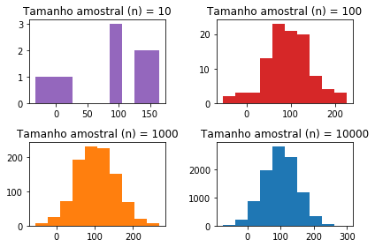

```python
print('Resposta:')
print('h10 = plt.hist(array_3b1)')
print('h100 = plt.hist(array_3b2)')
print('h1000 = plt.hist(array_3b3)')
print('h10000 = plt.hist(np.random.normal(100, math.sqrt(2500), 10000))')
fig, axes = plt.subplots(nrows=2, ncols=2)
ax0, ax1, ax2, ax3 = axes.flatten()
ax0.hist(array_3b1, color="tab:purple")
ax0.set_title('Tamanho amostral (n) = 10')
ax1.hist(array_3b2, color="tab:red")
ax1.set_title('Tamanho amostral (n) = 100')
ax2.hist(array_3b3, color="tab:orange")
ax2.set_title('Tamanho amostral (n) = 1000')
ax3.hist(np.random.normal(100, math.sqrt(2500), 10000), color="tab:blue")
ax3.set_title('Tamanho amostral (n) = 10000')
fig.tight_layout()
plt.show()
```

**EXERCÍCIO 04:**

**a) O arquivo dados.txt contem a avaliação de genótipos (primeira coluna) em repetições (segunda coluna) quanto a quatro variáveis (terceira coluna em diante). Portanto, carregue o arquivo dados.txt com a biblioteca numpy, apresente os dados e obtenha as informações de dimensão desta matriz.**

```python
print('Resposta: ')
dados = np.loadtxt('dados.txt')
#dados = np.array([1,1,249.75,604.15,404.48,348.49,281.31],[1,2,227.56,527.36,414.52,324.32,210.29],[1,3,368.18,711.87,490.14,331.84,297.12],[2,1,615.42,548.00,359.91,376.66,593.01],[2,2,756.11,59.78, 363.74,351.99,523.45],[2,3,481.54,464.04,415.98,317.41,447.33],[3,1,610.40,529.91,389.65,385.01,253.22],[3,2,534.73,436.40,439.23,400.99,241.25],[3,3,488.87,277.88,414.90,367.00,77.56],[4,1,587.84,186.90,399.76,556.27,55.25],[4,2,627.27,478.44,470.98,501.10,312.92],[4,3,594.91,454.60,409.16,429.03,268.36],[5,1,358.48,480.34,530.92,273.63,321.65],[5,2,341.18,238.63,414.71,344.45,370.12],[5,3,409.65,537.39,566.61,278.46,417.95],[6,1,530.40,430.57,309.84,245.79,552.34],[6,2,644.79,352.27,311.07,226.46,437.38],[6,3,619.42,256.40,287.13,294.35,714.34],[7,1,592.22,563.79,298.57,260.88,508.33],[7,2,588.89,862.62,502.44,260.02,351.95],[7,3,627.72,521.22,400.76,256.94,432.98],[8,1,605.05,420.44,303.72,265.78,549.18],[8,2,620.72,519.95,303.81,321.96,451.01],[8,3,711.55,375.29,274.21,227.00,459.69],[9,1,493.93,425.79,361.44,300.38,29.60],[9,2,457.53,450.88,335.19,286.33,239.92],[9,3,366.90,264.96,434.37,285.10,14.92],[10,1, 479.98,611.18,302.20,336.88,700.12],[10,2,671.50,372.21,270.94,302.40,461.48],[10,3, 471.44,284.37,300.48,383.68,851.41])
print('Conjunto de dados')
print('    Gen    Rep    v1     v2     v3     v4     v5')
np.set_printoptions(precision=2)
np.set_printoptions(suppress=True)
print(str(dados))
print(' ')
print('Dimensões dos conjunto de dados')
nlin, ncol = dados.shape
print('Número de linhas: {}'.format(nlin))
print('Número de colunas: {}'.format(ncol))
```

```
Resposta:
Conjunto de dados
    Gen    Rep    v1     v2     v3     v4     v5
[[  1.     1.   249.75 604.15 404.48 348.49 281.31]
 [  1.     2.   227.56 527.36 414.52 324.32 210.29]
 [  1.     3.   368.18 711.87 490.14 331.84 297.12]
 [  2.     1.   615.42 548.   359.91 376.66 593.01]
 [  2.     2.   756.11  59.78 363.74 351.99 523.45]
 [  2.     3.   481.54 464.04 415.98 317.41 447.33]
 [  3.     1.   610.4  529.91 389.65 385.01 253.22]
 [  3.     2.   534.73 436.4  439.23 400.99 241.25]
 [  3.     3.   488.87 277.88 414.9  367.    77.56]
 [  4.     1.   587.84 186.9  399.76 556.27  55.25]
 [  4.     2.   627.27 478.44 470.98 501.1  312.92]
 [  4.     3.   594.91 454.6  409.16 429.03 268.36]
 [  5.     1.   358.48 480.34 530.92 273.63 321.65]
 [  5.     2.   341.18 238.63 414.71 344.45 370.12]
 [  5.     3.   409.65 537.39 566.61 278.46 417.95]
 [  6.     1.   530.4  430.57 309.84 245.79 552.34]
 [  6.     2.   644.79 352.27 311.07 226.46 437.38]
 [  6.     3.   619.42 256.4  287.13 294.35 714.34]
 [  7.     1.   592.22 563.79 298.57 260.88 508.33]
 [  7.     2.   588.89 862.62 502.44 260.02 351.95]
 [  7.     3.   627.72 521.22 400.76 256.94 432.98]
 [  8.     1.   605.05 420.44 303.72 265.78 549.18]
 [  8.     2.   620.72 519.95 303.81 321.96 451.01]
 [  8.     3.   711.55 375.29 274.21 227.   459.69]
 [  9.     1.   493.93 425.79 361.44 300.38  29.6 ]
 [  9.     2.   457.53 450.88 335.19 286.33 239.92]
 [  9.     3.   366.9  264.96 434.37 285.1   14.92]
 [ 10.     1.   479.98 611.18 302.2  336.88 700.12]
 [ 10.     2.   671.5  372.21 270.94 302.4  461.48]
 [ 10.     3.   471.44 284.37 300.48 383.68 851.41]]

Dimensões dos conjunto de dados
Número de linhas: 30
Número de colunas: 7
```

**b) Pesquise sobre as funções np.unique e np.where da biblioteca numpy.**

```python
print('Resposta:')
print('help(np.unique) <- Este comando dará as instruções em inglês sobre a função np.unique da biblioteca numpy.')
print(' ')
help(np.unique)
print(' ')
print('help(np.where) <- Este comando dará as instruções em inglês sobre a função np.where da biblioteca numpy.')
print(' ')
help(np.where)
```

[output not shown]

[output cut: 130 more lines]

[output not shown]

**c) Obtenha de forma automática os genótipos e quantas repetições foram avaliadas.**

```python
print('Resposta:')
print('Os Genótipos {} foram avaliados em experimento com {} repetições por genótipo.'.format(np.unique(dados[:, 0]),int(max(dados[:, 1]))))
```

```
Resposta:
Os Genótipos [ 1.  2.  3.  4.  5.  6.  7.  8.  9. 10.] foram avaliados em experimento com 3 repetições por genótipo.
```

**d) Apresente uma matriz contendo somente as colunas 1, 2 e 4.**

```python
dados_v2 = dados[:, [0, 1, 3]]
print('Respota:')
print('Matriz com informações de Genótipos, Repetições e dados coletados da v2:')
print(' ')
print('   Gen    Rep     v2')
print(dados_v2)
```

```
Respota:
Matriz com informações de Genótipos, Repetições e dados coletados da v2:

   Gen    Rep     v2
[[  1.     1.   604.15]
 [  1.     2.   527.36]
 [  1.     3.   711.87]
 [  2.     1.   548.  ]
 [  2.     2.    59.78]
 [  2.     3.   464.04]
 [  3.     1.   529.91]
 [  3.     2.   436.4 ]
 [  3.     3.   277.88]
 [  4.     1.   186.9 ]
 [  4.     2.   478.44]
 [  4.     3.   454.6 ]
 [  5.     1.   480.34]
 [  5.     2.   238.63]
 [  5.     3.   537.39]
 [  6.     1.   430.57]
 [  6.     2.   352.27]
 [  6.     3.   256.4 ]
 [  7.     1.   563.79]
 [  7.     2.   862.62]
 [  7.     3.   521.22]
 [  8.     1.   420.44]
 [  8.     2.   519.95]
 [  8.     3.   375.29]
 [  9.     1.   425.79]
 [  9.     2.   450.88]
 [  9.     3.   264.96]
 [ 10.     1.   611.18]
 [ 10.     2.   372.21]
 [ 10.     3.   284.37]]
```

**e) Obtenha uma matriz que contenha o máximo, o mínimo, a média e a variância de cada genótipo para a variavel da coluna 4. Salve esta matriz em bloco de notas.**

```python
print('Resposta:')
matriz_v2 = np.zeros((len(np.unique(dados_v2[:, 0])), 5))
it = 0
for i in range(0, len(np.unique(dados_v2[:, 0])), 1):
    it = it + 1
    print(' ')
    print('O genótipo {} apresenta as seguintes informaçãos para a variável da coluna 4 (v2):'.format(it))
    print('Valor máximo: {} '.format(np.max((dados_v2[dados_v2[:, 0] == i + 1])[:, 2])))
    print('Valor minímo: {} '.format(np.min((dados_v2[dados_v2[:, 0] == i + 1])[:, 2])))
    print('Média: {} '.format(np.around(np.mean((dados_v2[dados_v2[:, 0] == i + 1])[:, 2]), 2)))
    print('Variância: {} '.format(np.around(np.var((dados_v2[dados_v2[:, 0] == i + 1])[:, 2]), 2)))
    matriz_v2[i, 0] = i + 1
    matriz_v2[i, 1] = np.max((dados_v2[dados_v2[:, 0] == i + 1])[:, 2])
    matriz_v2[i, 2] = np.min((dados_v2[dados_v2[:, 0] == i + 1])[:, 2])
    matriz_v2[i, 3] = np.around(np.mean((dados_v2[dados_v2[:, 0] == i + 1])[:, 2]), 2)
    matriz_v2[i, 4] = np.around(np.var((dados_v2[dados_v2[:, 0] == i + 1])[:, 2]), 2)

np.savetxt('Matriz_4e.txt', matriz_v2, fmt='%2.2f', delimiter='\t')
print(' ')
print(' ')
print('Informações da matriz:')
print(' ')
print('  Genótipo   Máximo   Minímo   Média   Variância')
print(matriz_v2)
print(' ')
print(' ')

print('f) Obtenha os genótipos que possuem média (médias das repetições) igual ou superior a 500 da matriz gerada na letra anterior.')
print(' ')
u_maiorq500 = matriz_v2[:, 3] >= 500
matriz_v2_maiorq500 = matriz_v2[u_maiorq500]
print('Quanto a v2, Os genótipos {} apresentaram as médias iguais ou superiores a 500.'.format(matriz_v2_maiorq500[:, 0]) )
```

```
Resposta:

O genótipo 1 apresenta as seguintes informaçãos para a variável da coluna 4 (v2):
Valor máximo: 711.87
Valor minímo: 527.36
Média: 614.46
Variância: 5727.14

O genótipo 2 apresenta as seguintes informaçãos para a variável da coluna 4 (v2):
Valor máximo: 548.0
Valor minímo: 59.78
Média: 357.27
Variância: 45426.02

O genótipo 3 apresenta as seguintes informaçãos para a variável da coluna 4 (v2):
Valor máximo: 529.91
Valor minímo: 277.88
Média: 414.73
Variância: 10821.31

O genótipo 4 apresenta as seguintes informaçãos para a variável da coluna 4 (v2):
Valor máximo: 478.44
Valor minímo: 186.9
Média: 373.31
Variância: 17469.69

O genótipo 5 apresenta as seguintes informaçãos para a variável da coluna 4 (v2):
Valor máximo: 537.39
Valor minímo: 238.63
Média: 418.79
Variância: 16770.66

O genótipo 6 apresenta as seguintes informaçãos para a variável da coluna 4 (v2):
Valor máximo: 430.57
Valor minímo: 256.4
Média: 346.41
Variância: 5073.02

O genótipo 7 apresenta as seguintes informaçãos para a variável da coluna 4 (v2):
Valor máximo: 862.62
```

[output cut: 26 more lines]

```
[[    1.     711.87   527.36   614.46  5727.14]
 [    2.     548.      59.78   357.27 45426.02]
 [    3.     529.91   277.88   414.73 10821.31]
 [    4.     478.44   186.9    373.31 17469.69]
 [    5.     537.39   238.63   418.79 16770.66]
 [    6.     430.57   256.4    346.41  5073.02]
 [    7.     862.62   521.22   649.21 23073.95]
 [    8.     519.95   375.29   438.56  3651.92]
 [    9.     450.88   264.96   380.54  6784.67]
 [   10.     611.18   284.37   422.59 19069.7 ]]


f) Obtenha os genótipos que possuem média (médias das repetições) igual ou superior a 500 da matriz gerada na letra anterior.

Quanto a v2, Os genótipos [1. 7.] apresentaram as médias iguais ou superiores a 500.
```

**g) Apresente os seguintes graficos:**

**- Médias dos genótipos para cada variável. Utilizar o comando plt.subplot para mostrar mais de um grafico por figura:**

```
Resposta:
As médias dos genótipos em cada variável:

 Genótipo    v1     v2     v3     v4     v5
[[  1.   281.83 614.46 436.38 334.88 262.91]
 [  2.   617.69 357.27 379.88 348.69 521.26]
 [  3.   544.67 414.73 414.59 384.33 190.68]
 [  4.   603.34 373.31 426.63 495.47 212.18]
 [  5.   369.77 418.79 504.08 298.85 369.91]
 [  6.   598.2  346.41 302.68 255.53 568.02]
 [  7.   602.94 649.21 400.59 259.28 431.09]
 [  8.   645.77 438.56 293.91 271.58 486.63]
 [  9.   439.45 380.54 377.   290.6   94.81]
 [ 10.   540.97 422.59 291.21 340.99 671.  ]]
```

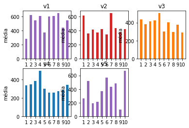

```python
matriz_completa = np.zeros((len(np.unique(dados[:, 0])), 6))
it = 0
for i in range(0, len(np.unique(dados[:, 0])), 1):
    it = it + 1
    matriz_completa[i, 0] = i + 1
    matriz_completa[i, 1] = np.around(np.mean((dados[dados[:, 0] == i + 1])[:, 2]), 2)
    matriz_completa[i, 2] = np.around(np.mean((dados[dados[:, 0] == i + 1])[:, 3]), 2)
    matriz_completa[i, 3] = np.around(np.mean((dados[dados[:, 0] == i + 1])[:, 4]), 2)
    matriz_completa[i, 4] = np.around(np.mean((dados[dados[:, 0] == i + 1])[:, 5]), 2)
    matriz_completa[i, 5] = np.around(np.mean((dados[dados[:, 0] == i + 1])[:, 6]), 2)

print(' ')
print('Resposta:')
print('As médias dos genótipos em cada variável:')
print(' ')
print(' Genótipo    v1     v2     v3     v4     v5')
print(matriz_completa)
print(' ')
print(' ')


plt.figure('As médias dos genótipos em cada variável')
plt.subplot(2, 3, 1)
plt.bar(x=matriz_completa[:, 0], height=matriz_completa[:, 1], width=0.5, align='center', color="tab:purple")
plt.title('v1')
plt.xticks(matriz_completa[:, 0])
plt.ylabel("média")

plt.subplot(2, 3, 2)
plt.bar(x=matriz_completa[:, 0], height=matriz_completa[:, 2], width=0.5, align='center', color="tab:red")
plt.title('v2')
plt.xticks(matriz_completa[:, 0])
plt.ylabel("média")

plt.subplot(2, 3, 3)
plt.bar(x=matriz_completa[:, 0], height=matriz_completa[:, 3], width=0.5, align='center', color="tab:orange")
plt.title('v3')
plt.xticks(matriz_completa[:, 0])
plt.ylabel("média")

plt.subplot(2, 3, 4)
plt.bar(x=matriz_completa[:, 0], height=matriz_completa[:, 4], width=0.5, align='center', color="tab:blue")
plt.title('v4')
plt.xticks(matriz_completa[:, 0])
plt.ylabel("média")

plt.subplot(2, 3, 5)
plt.bar(x=matriz_completa[:, 0], height=matriz_completa[:, 5], width=0.5, align='center', color="tab:purple")
plt.title('v5')
plt.xticks(matriz_completa[:, 0])
plt.ylabel("média")
fig.tight_layout()
plt.show()
```

**- Disperão 2D da médias dos genótipos (Utilizar as três primeiras variáveis). No eixo X uma variável e no eixo Y outra.**

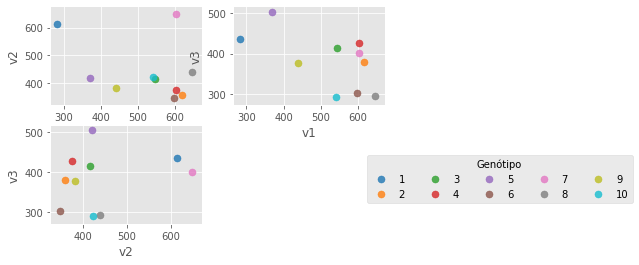

```python
cores = ['tab:blue', 'tab:orange', 'tab:green', 'tab:red', 'tab:purple', 'tab:brown','tab:pink', 'tab:gray', 'tab:olive', 'tab:cyan']

plt.style.use('ggplot')
plt.figure('2D Scatter Graph')

plt.subplot(2, 2, 1)
for i in np.arange(0, len(np.unique(dados[:, 0])), 1):
    plt.scatter(matriz_completa[i, 1], matriz_completa[i, 2], s=50, alpha=0.8, label=int(matriz_completa[i, 0]), c=cores[i])
plt.xlabel('v1')
plt.ylabel('v2')

plt.subplot(2, 2, 2)
for i in np.arange(0, len(np.unique(dados[:, 0])), 1):
    plt.scatter(matriz_completa[i, 1], matriz_completa[i, 3], s=50, alpha=0.8, label=int(matriz_completa[i, 0]), c=cores[i])
plt.xlabel('v1')
plt.ylabel('v3')

plt.subplot(2, 2, 3)
for i in np.arange(0, len(np.unique(dados[:, 0])), 1):
    plt.scatter(matriz_completa[i, 2], matriz_completa[i, 3], s=50, alpha=0.8, label=int(matriz_completa[i, 0]), c=cores[i])
plt.xlabel('v2')
plt.ylabel('v3')

plt.legend(bbox_to_anchor=(2.08, 0.7), title='Genótipo', borderaxespad=0., ncol=5)
plt.show()
```